Skip to content

[figure not shown]

# Student-t Mixtures: Robust Clustering with Heavy Tails

A Gaussian mixture is only as robust as its Gaussian components. Each component's mean and covariance are (weighted) averages of the points assigned to it, so a few far-away points -- contamination, sensor glitches, a stray cluster nobody asked for -- can drag a component's mean and inflate its covariance without limit. `StudentTMixture` (Peel & McLachlan, 2000) replaces every Gaussian component by a multivariate **Student-t** distribution. The t has the same bell-shaped core but polynomially decaying tails, and EM then *automatically downweights* points that are far from their component: a per-sample weight $u_{ik}$ shrinks toward zero with Mahalanobis distance.

The model is built on the same `BaseMixture` machinery as `GaussianMixture` (so `fit`, `predict`, `score`, `bic`/`aic`/`icl`, `algorithm`, `temperature`, `step_size`, `n_init`, semi-supervised `labels=` all work the same way), so it is a drop-in replacement whenever you suspect heavy-tailed noise.

**What you'll learn**

- how a Student-t density differs from a Gaussian, and what the degrees of freedom $\nu$ control;
- the scale-mixture representation that makes EM tractable, and the robustness weights $u_{ik}$ it produces;
- the ECM updates for $\mu_k$, $\Sigma_k$ and $\nu_k$ that `StudentTMixture` performs;
- how much better the model resists contamination than `GaussianMixture`, and how to flag outliers with `sample_weights`;
- how to recover a known degrees-of-freedom value, choose between `per_component` / `shared` / fixed `dof`, and compare information criteria with a Gaussian fit.

**Prerequisites:** 01 -- Gaussian Mixture Models and 02 -- The EM Algorithm. See also the Other Mixture Families user guide.

## Setup

The next cell imports what the notebook needs and fixes the random seeds. It expects `tgmm` to be importable: `pip install tgmm`, or `pip install -e .` from a clone of the repository. Opened with `marimo edit --sandbox`, the dependencies listed in the header of this file are installed automatically.

```python
import numpy as np
import torch
import matplotlib.pyplot as plt
from scipy import stats

from tgmm import GaussianMixture, StudentTMixture, plot_gmm
from tgmm.metrics import ClusteringMetrics
from tgmm.plotting import CATEGORICAL_PALETTE

plt.rcParams['figure.dpi'] = 100  # tgmm's theme uses 300 dpi; marimo embeds figures at 2x, so keep outputs small
SEED = 42
np.random.seed(SEED)
torch.manual_seed(SEED)
device = 'cuda' if torch.cuda.is_available() else 'cpu'
print(f'Using device: {device}')
```

import numpy as np import torch import matplotlib.pyplot as plt from scipy import stats from tgmm import GaussianMixture, StudentTMixture, plot_gmm from tgmm.metrics import ClusteringMetrics from tgmm.plotting import CATEGORICAL_PALETTE plt.rcParams['figure.dpi'] = 100 # tgmm's theme uses 300 dpi; marimo embeds figures at 2x, so keep outputs small SEED = 42 np.random.seed(SEED) torch.manual_seed(SEED) device = 'cuda' if torch.cuda.is_available() else 'cpu' print(f'Using device: {device}')

```
Using device: cpu
```

## Heavy tails: Student-t versus Gaussian

In $d$ dimensions the Student-t distribution with mean $\mu$, scale matrix $\Sigma$ and $\nu>0$ degrees of freedom has density

$$ t(x\mid\mu,\Sigma,\nu)= \frac{\Gamma\!\big(\tfrac{\nu+d}{2}\big)}{\Gamma\!\big(\tfrac{\nu}{2}\big)\,(\nu\pi)^{d/2}\,|\Sigma|^{1/2}} \Big(1+\frac{\delta}{\nu}\Big)^{-\frac{\nu+d}{2}},\qquad \delta=(x-\mu)^{\top}\Sigma^{-1}(x-\mu). $$

Compare with the Gaussian, whose density decays like $e^{-\delta/2}$: the t decays only like a *power* of $\delta$. Small $\nu$ means very heavy tails ($\nu=1$ is the Cauchy distribution, with no mean); as $\nu\to\infty$ the t converges to the Gaussian. The plots show the one-dimensional densities, linearly and on a log scale, where the tail behaviour is unmistakable.

!!! note "Scale matrix versus covariance" $\Sigma$ is the **scale matrix**, which is what `covariances_` stores. For $\nu>2$ the actual covariance of the distribution is $\frac{\nu}{\nu-2}\Sigma$; for $\nu\le2$ it is infinite.

```python
x = np.linspace(-8, 8, 801)
nus = [1, 3, 10, np.inf]
_fig, _axes = plt.subplots(1, 2, figsize=(13, 4.5))
for _nu, _color in zip(nus, CATEGORICAL_PALETTE):
    pdf = stats.norm.pdf(x) if np.isinf(_nu) else stats.t.pdf(x, df=_nu)
    label = 'Gaussian ($\\nu=\\infty$)' if np.isinf(_nu) else f'$\\nu={_nu}$'
    _axes[0].plot(x, pdf, color=_color, label=label)
    _axes[1].semilogy(x, pdf, color=_color, label=label)
_axes[0].set_title('Density')
_axes[1].set_title('Log density: the Gaussian tail collapses, the t tails do not')
_axes[1].set_ylim(1e-12, 1)
for _ax in _axes:
    _ax.set_xlabel('$x$')
    _ax.legend()
plt.tight_layout()
plt.gcf()
```

x = np.linspace(-8, 8, 801) nus = [1, 3, 10, np.inf] _fig, _axes = plt.subplots(1, 2, figsize=(13, 4.5)) for _nu, _color in zip(nus, CATEGORICAL_PALETTE): pdf = stats.norm.pdf(x) if np.isinf(_nu) else stats.t.pdf(x, df=_nu) label = 'Gaussian ($\\nu=\\infty$)' if np.isinf(_nu) else f'$\\nu={_nu}$' _axes[0].plot(x, pdf, color=_color, label=label) _axes[1].semilogy(x, pdf, color=_color, label=label) _axes[0].set_title('Density') _axes[1].set_title('Log density: the Gaussian tail collapses, the t tails do not') _axes[1].set_ylim(1e-12, 1) for _ax in _axes: _ax.set_xlabel('$x$') _ax.legend() plt.tight_layout() plt.gcf()

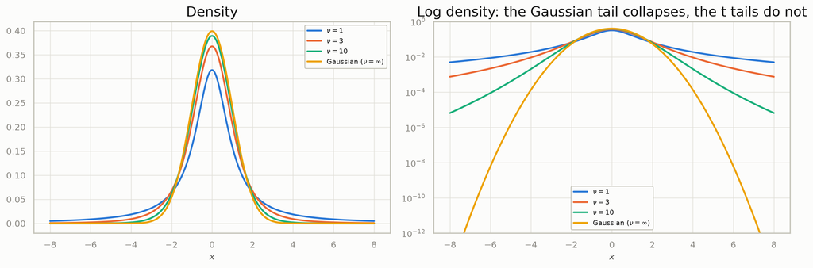

## The scale-mixture representation

The key to fitting a t-mixture is that a Student-t is a *Gaussian with a random precision*. Draw a latent multiplier $w\sim\mathrm{Gamma}(\nu/2,\ \nu/2)$ (shape / rate, so $\mathbb{E}[w]=1$) and then $x\mid w\sim\mathcal{N}(\mu,\ \Sigma/w)$; marginalising over $w$ gives exactly the t density above. A small $w$ inflates the variance: those are the far-out points. `StudentTMixture.sample` uses this recipe directly.

The scatter plots draw 600 points from a Gaussian and from a t with $\nu=2$ (same scale matrix), and colour the t points by their latent $\log w$. The t cloud has the same dense core but a halo of distant points, and the distant ones are precisely those with a small $w$.

```python
rng = np.random.default_rng(SEED)
n_demo, nu_demo = (600, 2.0)
z = rng.standard_normal((n_demo, 2))
w = rng.gamma(shape=nu_demo / 2, scale=2 / nu_demo, size=n_demo)  # rate nu/2 -> scale 2/nu
x_gauss = z
x_t = z / np.sqrt(w)[:, None]
_fig, _axes = plt.subplots(1, 2, figsize=(12, 5.2), sharex=True, sharey=True)
_axes[0].scatter(*x_gauss.T, s=8, color=CATEGORICAL_PALETTE[0])
_axes[0].set_title('Gaussian, $\\Sigma=I$')
_sc = _axes[1].scatter(*x_t.T, s=8, c=np.log(w), cmap='viridis_r', vmin=-4, vmax=1.5)
_axes[1].set_title(f'Student-t, $\\nu={nu_demo:g}$, $\\Sigma=I$ (colour: latent $\\log w$)')
_fig.colorbar(_sc, ax=_axes[1], label='$\\log w$')
for _ax in _axes:
    _ax.set_xlim(-12, 12)
    _ax.set_ylim(-12, 12)
    _ax.set_aspect('equal')
plt.tight_layout()
plt.gcf()
```

rng = np.random.default_rng(SEED) n_demo, nu_demo = (600, 2.0) z = rng.standard_normal((n_demo, 2)) w = rng.gamma(shape=nu_demo / 2, scale=2 / nu_demo, size=n_demo) # rate nu/2 -> scale 2/nu x_gauss = z x_t = z / np.sqrt(w)[:, None] _fig, _axes = plt.subplots(1, 2, figsize=(12, 5.2), sharex=True, sharey=True) _axes[0].scatter(*x_gauss.T, s=8, color=CATEGORICAL_PALETTE[0]) _axes[0].set_title('Gaussian, $\\Sigma=I$') _sc = _axes[1].scatter(*x_t.T, s=8, c=np.log(w), cmap='viridis_r', vmin=-4, vmax=1.5) _axes[1].set_title(f'Student-t, $\\nu={nu_demo:g}$, $\\Sigma=I$ (colour: latent $\\log w$)') _fig.colorbar(_sc, ax=_axes[1], label='$\\log w$') for _ax in _axes: _ax.set_xlim(-12, 12) _ax.set_ylim(-12, 12) _ax.set_aspect('equal') plt.tight_layout() plt.gcf()

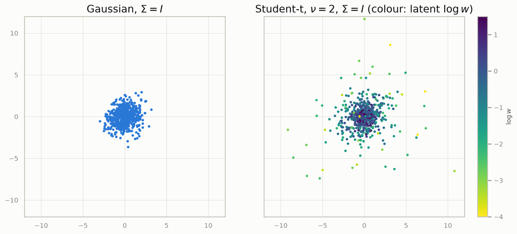

## EM for a Student-t mixture

**E-step.** Besides the usual responsibilities $r_{ik}$, the latent multiplier has a closed-form posterior given that $x_i$ came from component $k$: $w_{ik}\mid x_i\sim\mathrm{Gamma}\big(\tfrac{\nu_k+d}{2},\ \tfrac{\nu_k+\delta_{ik}}{2}\big)$, with mean

$$ u_{ik}=\mathbb{E}[w_{ik}\mid x_i,z_i=k]=\frac{\nu_k+d}{\nu_k+\delta_{ik}},\qquad \delta_{ik}=(x_i-\mu_k)^{\top}\Sigma_k^{-1}(x_i-\mu_k). $$

This is the **robustness weight**: points at the centre ($\delta\ll\nu$) get $u>1$, points far away ($\delta\gg\nu$) get $u\to0$. The plot shows $u$ as a function of the Mahalanobis distance for several $\nu$ (here $d=2$): small $\nu$ means a faster fall-off, i.e. more suspicion of distant points.

```python
delta = np.linspace(0, 60, 400)
d_demo = 2
plt.figure(figsize=(7, 4.5))
for _nu, _color in zip([1, 3, 10, 100], CATEGORICAL_PALETTE):
    plt.plot(delta, (_nu + d_demo) / (_nu + delta), color=_color, label=f'$\\nu={_nu}$')
plt.axhline(1.0, color='0.6', lw=1)
plt.xlabel('squared Mahalanobis distance $\\delta$')
plt.ylabel('robustness weight $u$')
plt.title(f'$u=(\\nu+d)/(\\nu+\\delta)$ for $d={d_demo}$')
plt.legend()
plt.gcf()
```

delta = np.linspace(0, 60, 400) d_demo = 2 plt.figure(figsize=(7, 4.5)) for _nu, _color in zip([1, 3, 10, 100], CATEGORICAL_PALETTE): plt.plot(delta, (_nu + d_demo) / (_nu + delta), color=_color, label=f'$\\nu={_nu}$') plt.axhline(1.0, color='0.6', lw=1) plt.xlabel('squared Mahalanobis distance $\\delta$') plt.ylabel('robustness weight $u$') plt.title(f'$u=(\\nu+d)/(\\nu+\\delta)$ for $d={d_demo}$') plt.legend() plt.gcf()

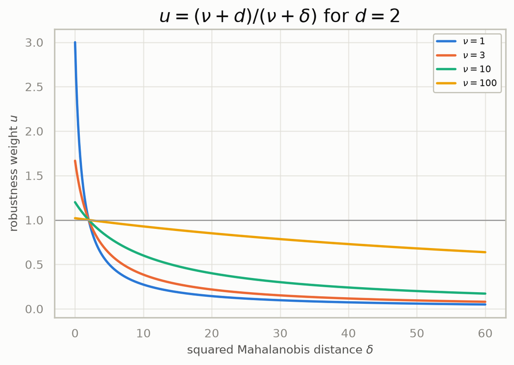

**M-step (ECM).** With $n_k=\sum_ir_{ik}$ and $m_k=\sum_ir_{ik}u_{ik}$:

$$ \pi_k=\frac{n_k}{n},\qquad \mu_k=\frac{\sum_ir_{ik}u_{ik}\,x_i}{m_k},\qquad \Sigma_k=\frac{\sum_ir_{ik}u_{ik}\,(x_i-\mu_k)(x_i-\mu_k)^{\top}}{n_k}. $$

These are the Gaussian updates with an extra weight $u_{ik}$ inside every sum, so a distant point contributes less the further away it is. As $\nu\to\infty$, $u_{ik}\to1$ and the updates reduce to the Gaussian ones. Each update uses the other parameters' values from the same iteration, which makes this an *ECM* (expectation conditional maximisation) algorithm. With `scale_update='ecme'` the covariance is divided by $m_k$ instead of $n_k$; at a fixed point the two coincide, because stationarity forces $\sum_ir_{ik}u_{ik}\delta_{ik}=d\,n_k$ and hence $m_k=n_k$.

**Degrees of freedom.** For `dof='per_component'` each $\nu_k$ solves, every M-step, the one-dimensional equation

$$ 1-\psi\!\Big(\frac{\nu}{2}\Big)+\ln\!\Big(\frac{\nu}{2}\Big)+c_k +\psi\!\Big(\frac{\nu+d}{2}\Big)-\ln\!\Big(\frac{\nu+d}{2}\Big)=0,\qquad c_k=\frac1{n_k}\sum_ir_{ik}\big(\ln u_{ik}-u_{ik}\big), $$

($\psi$ the digamma function), clamped to `dof_bounds`. `dof='shared'` pools $c$ across components and solves for one $\nu$; a numeric `dof` fixes it. The details, including where tgmm's step differs from the textbook one while sharing its fixed point, are in the user guide.

## Contaminated data: `StudentTMixture` versus `GaussianMixture`

Two well-separated clusters, plus 5% uniform-noise outliers scattered across the plot. A Gaussian component's covariance gets dragged toward any outliers it is forced to "explain"; a Student-t component's heavier tails let it downweight them instead.

```python
_gen = torch.Generator().manual_seed(SEED)
n_per = 250
true_centers = torch.tensor([[5.0, 5.0], [-5.0, -5.0]])
X_clean = torch.cat([torch.randn(n_per, 2, generator=_gen) * 0.6 + true_centers[0], torch.randn(n_per, 2, generator=_gen) * 0.6 + true_centers[1]])
n_out = int(0.05 * 2 * n_per)
outliers = (torch.rand(n_out, 2, generator=_gen) - 0.5) * 40
X = torch.cat([X_clean, outliers])
plt.figure(figsize=(5, 5))
plt.scatter(X[:-n_out, 0], X[:-n_out, 1], s=10, label='clean')
plt.scatter(X[-n_out:, 0], X[-n_out:, 1], s=10, c='red', marker='x', label='outliers')
plt.legend()
plt.title(f'{2 * n_per} clean points + {n_out} outliers (5%)')
plt.gcf()
```

_gen = torch.Generator().manual_seed(SEED) n_per = 250 true_centers = torch.tensor([[5.0, 5.0], [-5.0, -5.0]]) X_clean = torch.cat([torch.randn(n_per, 2, generator=_gen) * 0.6 + true_centers[0], torch.randn(n_per, 2, generator=_gen) * 0.6 + true_centers[1]]) n_out = int(0.05 * 2 * n_per) outliers = (torch.rand(n_out, 2, generator=_gen) - 0.5) * 40 X = torch.cat([X_clean, outliers]) plt.figure(figsize=(5, 5)) plt.scatter(X[:-n_out, 0], X[:-n_out, 1], s=10, label='clean') plt.scatter(X[-n_out:, 0], X[-n_out:, 1], s=10, c='red', marker='x', label='outliers') plt.legend() plt.title(f'{2 * n_per} clean points + {n_out} outliers (5%)') plt.gcf()

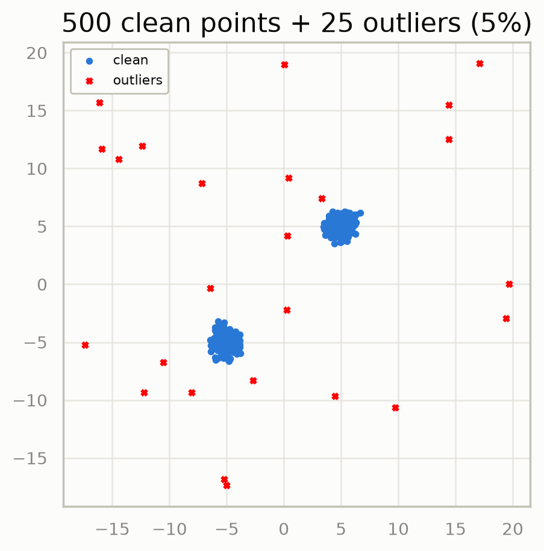

```python
gmm = GaussianMixture(n_components=2, random_state=SEED, n_init=5)
gmm.fit(X)

stm = StudentTMixture(n_components=2, covariance_type='full', dof='per_component',
                      random_state=SEED, n_init=5)
stm.fit(X)


def match_err(means, true_centers=true_centers):
    '''Mean distance between fitted and true centres, under the best matching.'''
    d = torch.cdist(means, true_centers)
    return min(d[0, 0] + d[1, 1], d[0, 1] + d[1, 0]).item() / 2


print(f'GaussianMixture mean error from truth:  {match_err(gmm.means_):.3f}')
print(f'StudentTMixture mean error from truth:  {match_err(stm.means_):.3f}')
print(f'StudentTMixture fitted dof_: {stm.dof_.tolist()}')
```

gmm = GaussianMixture(n_components=2, random_state=SEED, n_init=5) gmm.fit(X) stm = StudentTMixture(n_components=2, covariance_type='full', dof='per_component', random_state=SEED, n_init=5) stm.fit(X) def match_err(means, true_centers=true_centers): '''Mean distance between fitted and true centres, under the best matching.''' d = torch.cdist(means, true_centers) return min(d[0, 0] + d[1, 1], d[0, 1] + d[1, 0]).item() / 2 print(f'GaussianMixture mean error from truth: {match_err(gmm.means_):.3f}') print(f'StudentTMixture mean error from truth: {match_err(stm.means_):.3f}') print(f'StudentTMixture fitted dof_: {stm.dof_.tolist()}')

```
GaussianMixture mean error from truth:  0.258
StudentTMixture mean error from truth:  0.066
StudentTMixture fitted dof_: [1.40958833694458, 18.696617126464844]
```

```python
_fig, _axes = plt.subplots(1, 2, figsize=(11, 5))
plot_gmm(X, gmm=gmm, ax=_axes[0])
_axes[0].set_title(f'GaussianMixture (mean error {match_err(gmm.means_):.2f})')
plot_gmm(X, gmm=stm, ax=_axes[1])
_axes[1].set_title(f'StudentTMixture (mean error {match_err(stm.means_):.2f})')
plt.tight_layout()
plt.gcf()
```

_fig, _axes = plt.subplots(1, 2, figsize=(11, 5)) plot_gmm(X, gmm=gmm, ax=_axes[0]) _axes[0].set_title(f'GaussianMixture (mean error {match_err(gmm.means_):.2f})') plot_gmm(X, gmm=stm, ax=_axes[1]) _axes[1].set_title(f'StudentTMixture (mean error {match_err(stm.means_):.2f})') plt.tight_layout() plt.gcf()

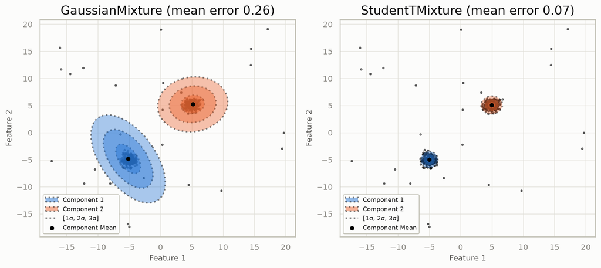

Look at the ellipses: the Gaussian fit stretches both components to swallow the outliers, while the t fit stays on the clusters. Note the fitted `dof_` -- small values say the model found heavy tails in this data. Because `covariances_` is the *scale matrix*, the t ellipses describe the bulk of each cluster, not its (much larger) actual covariance.

### Flagging outliers with `sample_weights`

`sample_weights(X)` returns each point's robustness weight $u_{i\hat z_i}$ at its predicted component -- small values are points the t-mixture effectively treated as outliers.

```python
weights = stm.sample_weights(X)
plt.figure(figsize=(5.5, 5))
_sc = plt.scatter(X[:, 0], X[:, 1], c=weights, cmap='viridis_r', s=12, vmin=0, vmax=1)
plt.colorbar(_sc, label='sample weight $u_{ik}$ (low = likely outlier)')
plt.title('StudentTMixture outlier weights')
plt.gcf()
```

weights = stm.sample_weights(X) plt.figure(figsize=(5.5, 5)) _sc = plt.scatter(X[:, 0], X[:, 1], c=weights, cmap='viridis_r', s=12, vmin=0, vmax=1) plt.colorbar(_sc, label='sample weight $u_{ik}$ (low = likely outlier)') plt.title('StudentTMixture outlier weights') plt.gcf()

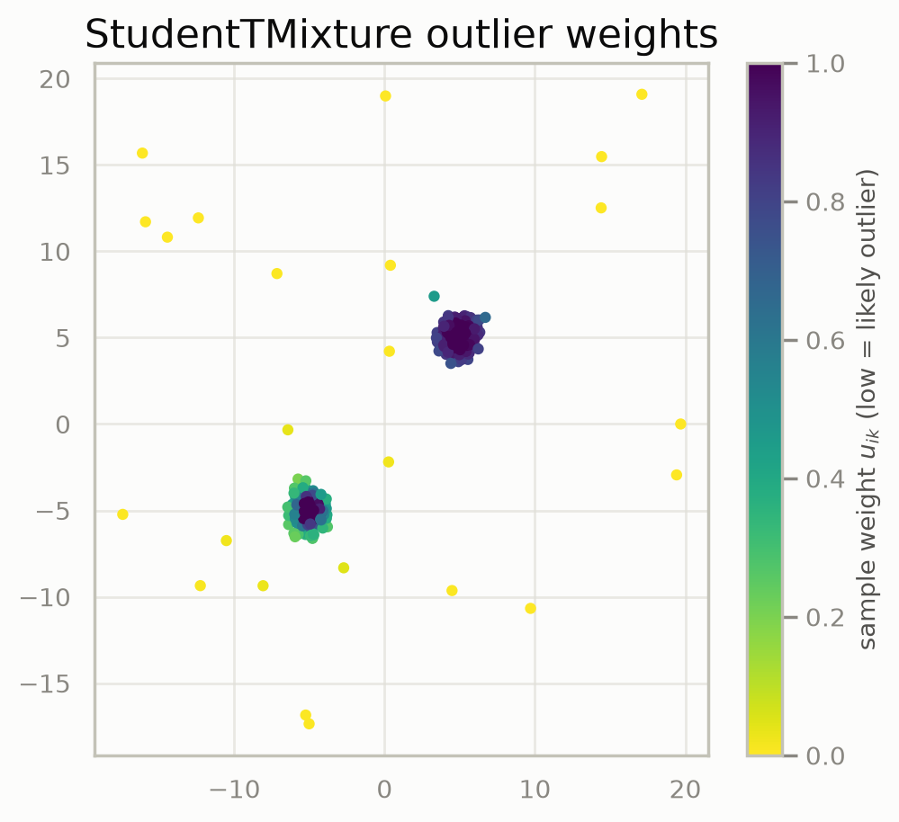

```python
print(f'Mean weight, clean points:      {weights[:-n_out].mean():.3f}')
print(f'Mean weight, injected outliers: {weights[-n_out:].mean():.3f}')
```

print(f'Mean weight, clean points: {weights[:-n_out].mean():.3f}') print(f'Mean weight, injected outliers: {weights[-n_out:].mean():.3f}')

```
Mean weight, clean points:      1.049
Mean weight, injected outliers: 0.027
```

## How much contamination can it take?

Repeat the experiment while increasing the fraction of uniform outliers from 0% to 20% and track how far each model's fitted centres end up from the truth. With no contamination the two models are equally good; as the fraction grows, the Gaussian centres drift while the t centres stay close to the truth.

```python
fractions = [0.0, 0.02, 0.05, 0.1, 0.15, 0.2]
err_gauss, err_t = ([], [])
for _frac in fractions:
    _gen = torch.Generator().manual_seed(1)
    _clean = torch.cat([torch.randn(n_per, 2, generator=_gen) * 0.6 + true_centers[0], torch.randn(n_per, 2, generator=_gen) * 0.6 + true_centers[1]])
    _n_o = int(_frac * 2 * n_per)
    _noise = (torch.rand(_n_o, 2, generator=_gen) - 0.5) * 40
    _X_f = torch.cat([_clean, _noise])
    _g = GaussianMixture(n_components=2, random_state=SEED, n_init=3).fit(_X_f)
    _t = StudentTMixture(n_components=2, random_state=SEED, n_init=3).fit(_X_f)
    err_gauss.append(match_err(_g.means_))
    err_t.append(match_err(_t.means_))
plt.figure(figsize=(7, 4.5))
plt.plot([100 * f for f in fractions], err_gauss, marker='o', label='GaussianMixture')
plt.plot([100 * f for f in fractions], err_t, marker='o', label='StudentTMixture')
plt.xlabel('fraction of uniform outliers (%)')
plt.ylabel('mean error of fitted centres')
plt.title('Robustness to contamination')
plt.legend()
plt.gcf()
```

fractions = [0.0, 0.02, 0.05, 0.1, 0.15, 0.2] err_gauss, err_t = ([], []) for _frac in fractions: _gen = torch.Generator().manual_seed(1) _clean = torch.cat([torch.randn(n_per, 2, generator=_gen) * 0.6 + true_centers[0], torch.randn(n_per, 2, generator=_gen) * 0.6 + true_centers[1]]) _n_o = int(_frac * 2 * n_per) _noise = (torch.rand(_n_o, 2, generator=_gen) - 0.5) * 40 _X_f = torch.cat([_clean, _noise]) _g = GaussianMixture(n_components=2, random_state=SEED, n_init=3).fit(_X_f) _t = StudentTMixture(n_components=2, random_state=SEED, n_init=3).fit(_X_f) err_gauss.append(match_err(_g.means_)) err_t.append(match_err(_t.means_)) plt.figure(figsize=(7, 4.5)) plt.plot([100 * f for f in fractions], err_gauss, marker='o', label='GaussianMixture') plt.plot([100 * f for f in fractions], err_t, marker='o', label='StudentTMixture') plt.xlabel('fraction of uniform outliers (%)') plt.ylabel('mean error of fitted centres') plt.title('Robustness to contamination') plt.legend() plt.gcf()

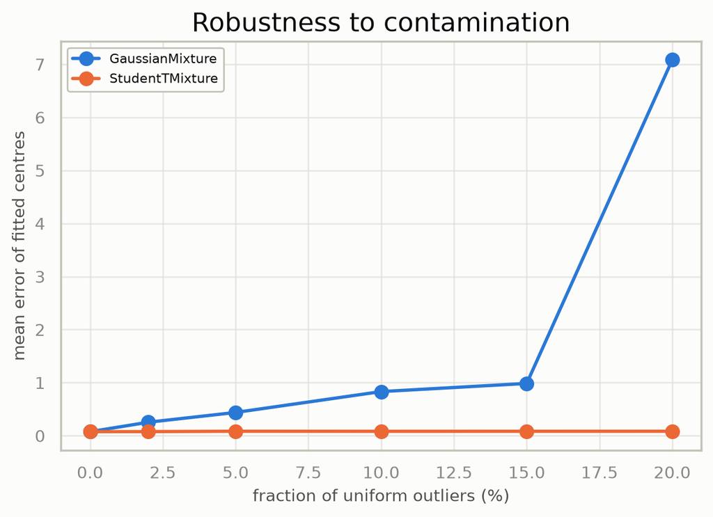

## Recovering the degrees of freedom

Because `dof_` is estimated by maximum likelihood, it should recover the tail heaviness the data was generated with. We simulate two clusters whose points are genuine Student-t draws with $\nu=3$ (via the scale-mixture recipe) and fit `per_component`, `shared`, and a fixed near-Gaussian `dof=1e4`. We also fit clean Gaussian data, where the estimate should drift towards the upper bound.

```python
def sample_t_clusters(nu, n_each, scale, seed):
    gen = torch.Generator().manual_seed(seed)
    parts, labels = ([], [])
    for k, c in enumerate(true_centers):
        z = torch.randn(n_each, 2, generator=gen)
        w = torch._standard_gamma(torch.full((n_each, 1), nu / 2), generator=gen) * (2.0 / nu)
        parts.append(c + scale * z / w.sqrt())
        labels.append(torch.full((n_each,), k))
    return (torch.cat(parts), torch.cat(labels))
X_t3, y_t3 = sample_t_clusters(nu=3.0, n_each=1000, scale=0.6, seed=3)
X_gauss, y_gauss = sample_t_clusters(nu=1000000.0, n_each=1000, scale=0.6, seed=4)  # effectively Gaussian
_rows = []
for _name, _data in [('t, nu = 3', X_t3), ('Gaussian', X_gauss)]:
    for _dof in ['per_component', 'shared', 10000.0]:
        _m = StudentTMixture(n_components=2, dof=_dof, random_state=SEED, n_init=2).fit(_data)
        _rows.append((_name, _dof, _m.dof_.numpy().round(2), round(_m.bic(_data), 1)))
for _r in _rows:
    print(f'{_r[0]:<10} dof={str(_r[1]):<14} fitted dof_={_r[2]}   BIC={_r[3]}')
```

def sample_t_clusters(nu, n_each, scale, seed): gen = torch.Generator().manual_seed(seed) parts, labels = ([], []) for k, c in enumerate(true_centers): z = torch.randn(n_each, 2, generator=gen) w = torch._standard_gamma(torch.full((n_each, 1), nu / 2), generator=gen) * (2.0 / nu) parts.append(c + scale * z / w.sqrt()) labels.append(torch.full((n_each,), k)) return (torch.cat(parts), torch.cat(labels)) X_t3, y_t3 = sample_t_clusters(nu=3.0, n_each=1000, scale=0.6, seed=3) X_gauss, y_gauss = sample_t_clusters(nu=1000000.0, n_each=1000, scale=0.6, seed=4) # effectively Gaussian _rows = [] for _name, _data in [('t, nu = 3', X_t3), ('Gaussian', X_gauss)]: for _dof in ['per_component', 'shared', 10000.0]: _m = StudentTMixture(n_components=2, dof=_dof, random_state=SEED, n_init=2).fit(_data) _rows.append((_name, _dof, _m.dof_.numpy().round(2), round(_m.bic(_data), 1))) for _r in _rows: print(f'{_r[0]:<10} dof={str(_r[1]):<14} fitted dof_={_r[2]} BIC={_r[3]}')

```
t, nu = 3  dof=per_component  fitted dof_=[3.24 3.29]   BIC=12843.1
t, nu = 3  dof=shared         fitted dof_=[3.26 3.26]   BIC=12835.5
t, nu = 3  dof=10000.0        fitted dof_=[10000. 10000.]   BIC=14410.4
Gaussian   dof=per_component  fitted dof_=[28.23 40.69]   BIC=10116.7
Gaussian   dof=shared         fitted dof_=[33.65 33.65]   BIC=10109.6
Gaussian   dof=10000.0        fitted dof_=[10000. 10000.]   BIC=10086.0
```

On the $\nu=3$ data the fitted `dof_` is close to the true value, and the free-$\nu$ models reach a lower BIC than the fixed near-Gaussian one. On Gaussian data `dof_` runs to large values (tens or more, drifting towards `dof_bounds[1]`): the model reports that the component is indistinguishable from a Gaussian, and `dof=1e4` is then an equally good fit with fewer parameters.

## ECM versus ECME

The `scale_update` option chooses how the scale matrix is normalised ($n_k$ for `'ecm'`, $m_k$ for `'ecme'`). Both reach the same fixed point; they take different paths to it.

```python
for _update in ['ecm', 'ecme']:
    _m = StudentTMixture(n_components=2, scale_update=_update, random_state=SEED, tol=1e-08, max_iter=500).fit(X)
    print(f"scale_update='{_update}': iterations={_m.n_iter_:>3}  log-likelihood/sample={_m.lower_bound_:.6f}  dof_={_m.dof_.numpy().round(3)}")
```

for _update in ['ecm', 'ecme']: _m = StudentTMixture(n_components=2, scale_update=_update, random_state=SEED, tol=1e-08, max_iter=500).fit(X) print(f"scale_update='{_update}': iterations={_m.n_iter_:>3} log-likelihood/sample={_m.lower_bound_:.6f} dof_={_m.dof_.numpy().round(3)}")

```
scale_update='ecm': iterations=104  log-likelihood/sample=-2.992571  dof_=[  1.386 746.982]
scale_update='ecme': iterations=102  log-likelihood/sample=-2.992570  dof_=[  1.386 746.982]
```

## Comparing with a Gaussian fit

Gaussian and Student-t mixtures both define densities on $\mathbb{R}^d$ with respect to the same (Lebesgue) measure, so their log-likelihoods and information criteria **are** directly comparable. (This is not true across families with different base measures, such as the von Mises-Fisher mixture on the sphere -- see the next tutorial.) On the contaminated data the t model is favoured even after paying for its extra $K$ degrees-of-freedom parameters:

```python
print(f'GaussianMixture   BIC = {gmm.bic(X):10.1f}   AIC = {gmm.aic(X):10.1f}')
print(f'StudentTMixture   BIC = {stm.bic(X):10.1f}   AIC = {stm.aic(X):10.1f}')

ari_g = ClusteringMetrics.adjusted_rand_score(torch.cat([torch.zeros(n_per), torch.ones(n_per)]).long(), gmm.predict(X)[:2 * n_per])
ari_t = ClusteringMetrics.adjusted_rand_score(torch.cat([torch.zeros(n_per), torch.ones(n_per)]).long(), stm.predict(X)[:2 * n_per])
print(f'ARI on the clean points:  Gaussian {ari_g:.3f}   Student-t {ari_t:.3f}')
```

print(f'GaussianMixture BIC = {gmm.bic(X):10.1f} AIC = {gmm.aic(X):10.1f}') print(f'StudentTMixture BIC = {stm.bic(X):10.1f} AIC = {stm.aic(X):10.1f}') ari_g = ClusteringMetrics.adjusted_rand_score(torch.cat([torch.zeros(n_per), torch.ones(n_per)]).long(), gmm.predict(X)[:2 * n_per]) ari_t = ClusteringMetrics.adjusted_rand_score(torch.cat([torch.zeros(n_per), torch.ones(n_per)]).long(), stm.predict(X)[:2 * n_per]) print(f'ARI on the clean points: Gaussian {ari_g:.3f} Student-t {ari_t:.3f}')

```
GaussianMixture   BIC =     5169.5   AIC =     5122.6
StudentTMixture   BIC =     3225.8   AIC =     3170.4
ARI on the clean points:  Gaussian 1.000   Student-t 1.000
```

## Summary

- A Student-t is a Gaussian with a random precision; its heavy tails are controlled by the degrees of freedom $\nu$ ($\nu\to\infty$ recovers the Gaussian).
- In EM this appears as a per-sample, per-component weight $u_{ik}=(\nu_k+d)/(\nu_k+\delta_{ik})$ that shrinks with Mahalanobis distance; the M-step is the Gaussian one with $u_{ik}$ inside the sums, and each $\nu_k$ is found by a one-dimensional root-finding step.
- `StudentTMixture` is a drop-in, more outlier-robust alternative to `GaussianMixture`: its centres stay on the clusters as contamination grows, and `sample_weights` points out which observations it distrusted.
- `dof_` recovers the tail heaviness of the data; a large `dof_` says the data are effectively Gaussian.
- `covariances_` holds the scale matrix, not the covariance; information criteria are comparable with a `GaussianMixture` fit on the same data.

**Next:** 17 -- Von Mises-Fisher Mixtures for directional data, or 18 -- Semi-Supervised and Positive-Unlabeled Fitting.